# Write a Data Science Blog Post

This blog post describes a data taken from kaggle "https://www.kaggle.com/himanshupoddar/zomato-bangalore-restaurants/kernels"

I was constantly captivated by the food culture of Bengaluru. Eateries from everywhere throughout the world can be found here in Bengaluru. From the United States to Japan, Russia to Antarctica, you get all kinds of cooking styles here. Conveyance, Dine-out, Pubs, Bars, Drinks, Buffet, Desserts, and so on, and Bengaluru has it. Bengaluru is the best spot for foodies. The quantity of cafe is expanding step by step. As of now which remains at roughly 12,000 cafes. With such a high number of eateries. This industry hasn't been soaked at this point. Also, new cafes are opening each day. Anyway, it has gotten hard for them to contend with previously settled eateries. The key issues that keep on representing a test to them incorporate high land costs, rising food costs, deficiency of value labor, divided gracefully chain, and over-authorizing. This Zomato information targets breaking down the demography of the area. Above all, it will help new eateries in choosing their topic, menus, food, cost, and so forth for a specific area. It additionally targets discovering likeness between neighborhoods of Bengaluru based on food. The dataset likewise contains audits for every one of the eateries which will help in discovering generally speaking ratings for the spot.

# Insights of the data

> The essential thought of breaking down the Zomato dataset is to get a reasonable thought regarding the variables influencing the foundation

> Out of various kinds of café at better places in Bengaluru, the total rating of every eatery, Bengaluru.

> Being one such city has in excess of 12,000 cafés with eateries serving dishes from everywhere throughout the world.

> With every day new cafés opening the business hasn't been immersed at this point and the interest is expanding step by step.

> Due expanding request, it anyway has gotten hard for new eateries to contend with set up cafés.

> The greater part of them serving similar food. Bengaluru being an IT capital of India.

> The majority of the individuals here are needy mostly on the eatery food as they don't have the opportunity to cook for themselves.

> With such a mind-boggling request of cafés, it has in this manner become critical to contemplate the demography of an area.

> What sort of food is increasingly well known in a territory. Do the whole territory adores veggie lover food.

> On the off chance that indeed, at that point is that region populated by a specific organization of individuals for eg. Jain, Marwaris, Gujaratis who are generally vegan.

```python
#imports of the basic essential libraries
import numpy as np
import pandas as pd
import seaborn as sns
from matplotlib import pyplot as plt
```

```python
#import dataset into the workspace
data = pd.read_csv('zomato.csv')
```

```python
data.shape
```

```
(51717, 17)
```

```python
data.info()
```

```
<class 'pandas.core.frame.DataFrame'>
RangeIndex: 51717 entries, 0 to 51716
Data columns (total 17 columns):
 #   Column                       Non-Null Count  Dtype
---  ------                       --------------  -----
 0   url                          51717 non-null  object
 1   address                      51717 non-null  object
 2   name                         51717 non-null  object
 3   online_order                 51717 non-null  object
 4   book_table                   51717 non-null  object
 5   rate                         43942 non-null  object
 6   votes                        51717 non-null  int64
 7   phone                        50509 non-null  object
 8   location                     51696 non-null  object
 9   rest_type                    51490 non-null  object
 10  dish_liked                   23639 non-null  object
 11  cuisines                     51672 non-null  object
 12  approx_cost(for two people)  51371 non-null  object
 13  reviews_list                 51717 non-null  object
 14  menu_item                    51717 non-null  object
 15  listed_in(type)              51717 non-null  object
 16  listed_in(city)              51717 non-null  object
dtypes: int64(1), object(16)
memory usage: 6.7+ MB
```

```python
data.describe()
```

|  | votes |
| --- | --- |
| count | 51717.000000 |
| mean | 283.697527 |
| std | 803.838853 |
| min | 0.000000 |
| 25% | 7.000000 |
| 50% | 41.000000 |
| 75% | 198.000000 |
| max | 16832.000000 |

```python
data.head(10)
```

|  | url | address | name | online_order | book_table | rate | votes | phone | location | rest_type | dish_liked | cuisines | approx_cost(for two people) | reviews_list | menu_item | listed_in(type) | listed_in(city) |
| --- | --- | --- | --- | --- | --- | --- | --- | --- | --- | --- | --- | --- | --- | --- | --- | --- | --- |
| 0 | https://www.zomato.com/bangalore/jalsa-banasha... | 942, 21st Main Road, 2nd Stage, Banashankari, ... | Jalsa | Yes | Yes | 4.1/5 | 775 | 080 42297555\r\n+91 9743772233 | Banashankari | Casual Dining | Pasta, Lunch Buffet, Masala Papad, Paneer Laja... | North Indian, Mughlai, Chinese | 800 | [('Rated 4.0', 'RATED\n A beautiful place to ... | [] | Buffet | Banashankari |
| 1 | https://www.zomato.com/bangalore/spice-elephan... | 2nd Floor, 80 Feet Road, Near Big Bazaar, 6th ... | Spice Elephant | Yes | No | 4.1/5 | 787 | 080 41714161 | Banashankari | Casual Dining | Momos, Lunch Buffet, Chocolate Nirvana, Thai G... | Chinese, North Indian, Thai | 800 | [('Rated 4.0', 'RATED\n Had been here for din... | [] | Buffet | Banashankari |
| 2 | https://www.zomato.com/SanchurroBangalore?cont... | 1112, Next to KIMS Medical College, 17th Cross... | San Churro Cafe | Yes | No | 3.8/5 | 918 | +91 9663487993 | Banashankari | Cafe, Casual Dining | Churros, Cannelloni, Minestrone Soup, Hot Choc... | Cafe, Mexican, Italian | 800 | [('Rated 3.0', "RATED\n Ambience is not that ... | [] | Buffet | Banashankari |
| 3 | https://www.zomato.com/bangalore/addhuri-udupi... | 1st Floor, Annakuteera, 3rd Stage, Banashankar... | Addhuri Udupi Bhojana | No | No | 3.7/5 | 88 | +91 9620009302 | Banashankari | Quick Bites | Masala Dosa | South Indian, North Indian | 300 | [('Rated 4.0', "RATED\n Great food and proper... | [] | Buffet | Banashankari |
| 4 | https://www.zomato.com/bangalore/grand-village... | 10, 3rd Floor, Lakshmi Associates, Gandhi Baza... | Grand Village | No | No | 3.8/5 | 166 | +91 8026612447\r\n+91 9901210005 | Basavanagudi | Casual Dining | Panipuri, Gol Gappe | North Indian, Rajasthani | 600 | [('Rated 4.0', 'RATED\n Very good restaurant ... | [] | Buffet | Banashankari |
| 5 | https://www.zomato.com/bangalore/timepass-dinn... | 37, 5-1, 4th Floor, Bosco Court, Gandhi Bazaar... | Timepass Dinner | Yes | No | 3.8/5 | 286 | +91 9980040002\r\n+91 9980063005 | Basavanagudi | Casual Dining | Onion Rings, Pasta, Kadhai Paneer, Salads, Sal... | North Indian | 600 | [('Rated 3.0', 'RATED\n Food 3/5\nAmbience 3/... | [] | Buffet | Banashankari |
| 6 | https://www.zomato.com/bangalore/rosewood-inte... | 19/1, New Timberyard Layout, Beside Satellite ... | Rosewood International Hotel - Bar & Restaurant | No | No | 3.6/5 | 8 | +91 9731716688\r\n080 26740366 | Mysore Road | Casual Dining | NaN | North Indian, South Indian, Andhra, Chinese | 800 | [('Rated 5.0', 'RATED\n Awesome food ??Great ... | [] | Buffet | Banashankari |
| 7 | https://www.zomato.com/bangalore/onesta-banash... | 2469, 3rd Floor, 24th Cross, Opposite BDA Comp... | Onesta | Yes | Yes | 4.6/5 | 2556 | 080 48653961\r\n080 48655715 | Banashankari | Casual Dining, Cafe | Farmhouse Pizza, Chocolate Banana, Virgin Moji... | Pizza, Cafe, Italian | 600 | [('Rated 5.0', 'RATED\n I personally really l... | [] | Cafes | Banashankari |
| 8 | https://www.zomato.com/bangalore/penthouse-caf... | 1, 30th Main Road, 3rd Stage, Banashankari, Ba... | Penthouse Cafe | Yes | No | 4.0/5 | 324 | +91 8884135549\r\n+91 9449449316 | Banashankari | Cafe | Pizza, Mocktails, Coffee, Nachos, Salad, Pasta... | Cafe, Italian, Continental | 700 | [('Rated 3.0', "RATED\n I had been to this pl... | [] | Cafes | Banashankari |
| 9 | https://www.zomato.com/bangalore/smacznego-ban... | 2470, 21 Main Road, 25th Cross, Banashankari, ... | Smacznego | Yes | No | 4.2/5 | 504 | +91 9945230807\r\n+91 9743804471 | Banashankari | Cafe | Waffles, Pasta, Coleslaw Sandwich, Choco Waffl... | Cafe, Mexican, Italian, Momos, Beverages | 550 | [('Rated 4.0', "RATED\n Easy to locate\nVFM 3... | [] | Cafes | Banashankari |

```python
data.isna().sum()
```

```
url                                0
address                            0
name                               0
online_order                       0
book_table                         0
rate                            7775
votes                              0
phone                           1208
location                          21
rest_type                        227
dish_liked                     28078
cuisines                          45
approx_cost(for two people)      346
reviews_list                       0
menu_item                          0
listed_in(type)                    0
listed_in(city)                    0
dtype: int64
```

# Cleaning Data

**lets clean the data buy:**

> Removing Unnecessary columns

> Removing Null values

> droping duplicates

```python
#Removing unnecessary columns
data.drop(['url','menu_item','dish_liked','phone','reviews_list'], axis=1, inplace=True)
data.head(10)
```

[output not shown]

```python
#Removing null values
data.dropna(how = 'any', inplace=True)
data.shape
```

[output not shown]

```python
#Removing duplicate values
data = data[data.duplicated() == False]
data.shape
```

[output not shown]

```python
#Assigning proper data type to the columns
data.info()
```

[output not shown]

```python
data['approx_cost(for two people)'] = data['approx_cost(for two people)'].str.replace(',','')
data['approx_cost_for_2'] = data['approx_cost(for two people)'].astype(int)
```

```python
data['approx_cost_for_2'].value_counts()
```

```
300     5706
400     5531
500     4294
200     3515
600     3341
        ...
560        1
3700       1
360        1
5000       1
160        1
Name: approx_cost_for_2, Length: 66, dtype: int64
```

# Visualizarion

**We will be finding some answers to the questions by ploting the graphs, to undestand the answer better.**

## Question 1

**Which type of restaurants are providing table booking facility in the bengaluru city?**

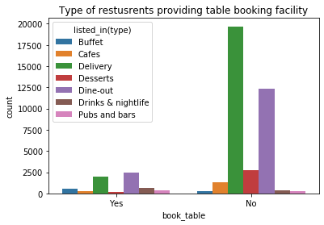

```python
sns.countplot(x=data['book_table'],hue= data['listed_in(type)'])
fig=plt.gcf()
plt.title('Type of restaurants providing table booking facility')
```

```python
book_no = data[data['book_table'] == 'No']
book_no =book_no['listed_in(type)'].value_counts().sort_index()
book_no
```

```
Buffet                  308
Cafes                  1312
Delivery              19685
Desserts               2710
Dine-out              12380
Drinks & nightlife      409
Pubs and bars           265
Name: listed_in(type), dtype: int64
```

```python
book_yes = data[data['book_table'] == 'Yes']
book_yes = book_yes['listed_in(type)'].value_counts().sort_index()
book_yes
```

```
Buffet                 557
Cafes                  277
Delivery              1943
Desserts               139
Dine-out              2450
Drinks & nightlife     664
Pubs and bars          395
Name: listed_in(type), dtype: int64
```

```python
diff = book_no - book_yes
diff
```

```
Buffet                 -249
Cafes                  1035
Delivery              17742
Desserts               2571
Dine-out               9930
Drinks & nightlife     -255
Pubs and bars          -130
Name: listed_in(type), dtype: int64
```

### Answer

> Not all the restaurants provide facilities of booking table cafes, delivery, Desserts and Dine-Out these restaurants prefer not to have table booking

> But the restaurants types like Buffet, Drinks & nightlife and Pubs & bars prefer to have a table book before you visit these restaurants.

## Question 2

**Which area in the city have more number of restaurants located?**

```python
fig=plt.figure(figsize=(40,200))
locationCount=data['location'].value_counts().sort_values(ascending=True)

locationCount.plot(kind='barh',fontsize=50)
plt.ylabel('Location Names',fontsize = 70)
plt.title('Restaurent Count graoh Vs Location',fontsize= 100)

for i in range(len(locationCount)):
    plt.text(i+locationCount[i],i,locationCount[i],fontsize=50)
```

[figure not shown]

```python
locationCount.nlargest(10)
```

```
BTM                      4203
Koramangala 5th Block    2357
HSR                      2101
Indiranagar              1888
JP Nagar                 1841
Jayanagar                1709
Whitefield               1677
Marathahalli             1470
Bannerghatta Road        1314
Koramangala 6th Block    1086
Name: location, dtype: int64
```

```python
locationCount.nsmallest(10)
```

```
Peenya                   1
Nagarbhavi               1
Rajarajeshwari Nagar     2
Yelahanka                4
West Bangalore           5
Kengeri                  8
Central Bangalore        8
Uttarahalli              9
Hebbal                  10
KR Puram                11
Name: location, dtype: int64
```

### Answer

**The top 10 areas with high number of restaurants are:**

- BTM 4203
- Koramangala 5th Block 2357
- HSR 2101
- Indiranagar 1888
- JP Nagar 1841
- Jayanagar 1709
- Whitefield 1677
- Marathahalli 1470
- Bannerghatta Road 1314
- Koramangala 6th Block 1086

**The top 10 areas with low number of restaurants are:**

- Peenya 1
- Nagarbhavi 1
- Rajarajeshwari Nagar 2
- Yelahanka 4
- West Bangalore 5
- Kengeri 8
- Central Bangalore 8
- Uttarahalli 9
- Hebbal 10
- KR Puram 11

## Question 3

**What are the cheapest and the costly prices of the restaurants in different parts ofthe city?**

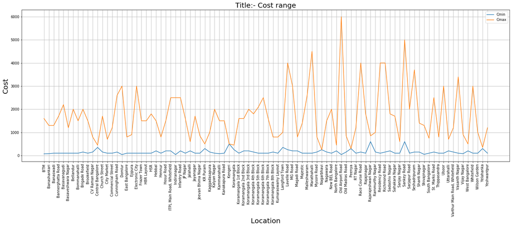

```python
temp = data.groupby('location')['approx_cost_for_2'].agg([('Cmin','min'), ('Cmax','max')])
ax = temp.plot(figsize=(25,8), grid=True)
ax.set_xticks(range(len(temp)))
ax.set_xticklabels(temp.index, rotation=90)
ax.set_xlabel('Location', fontsize=20)
ax.set_ylabel('Cost', fontsize=20)
ax.set_title('Title:- Cost range', fontsize=20)
plt.show()
```

```python
temp['Cmin'].nsmallest(5)
```

```
location
Domlur              40
Indiranagar         40
Old Airport Road    40
Shivajinagar        50
BTM                 70
Name: Cmin, dtype: int64
```

```python
temp['Cmax'].nlargest(5)
```

```
location
Old Airport Road    6000
Sankey Road         5000
Marathahalli        4500
Lavelle Road        4000
Race Course Road    4000
Name: Cmax, dtype: int64
```

### Answer

**These are some of the cheapest areas to find food:**

- Domlur 40
- Indiranagar 40
- Old Airport Road 40
- Shivajinagar 50
- BTM 70

**These are some of the costly areas to find food:**

- Old Airport Road 6000
- Sankey Road 5000
- Marathahalli 4500
- Lavelle Road 4000
- Race Course Road 4000